| title= “Practical Machine Learning Project” |
| --- |
| Author= “Jin Ye Kim” |
| 0utput: html_document |

## Background

Using devices such as Jawbone Up, Nike FuelBand, and Fitbit it is now possible to collect a large amount of data about personal activity relatively inexpensively. These type of devices are part of the quantified self movement ??? a group of enthusiasts who take measurements about themselves regularly to improve their health, to find patterns in their behavior, or because they are tech geeks. One thing that people regularly do is quantify how much of a particular activity they do, but they rarely quantify how well they do it. In this project, your goal will be to use data from accelerometers on the belt, forearm, arm, and dumbell of 6 participants. They were asked to perform barbell lifts correctly and incorrectly in 5 different ways. More information is available from the website here: http://groupware.les.inf.puc-rio.br/har (see the section on the Weight Lifting Exercise Dataset).

This project is Data Scientist Specialization’s Practical Machine Learning course assignment in Coursera.

## Data Overview

In this work (see the paper) we first define quality of execution and investigate three aspects that pertain to qualitative activity recognition: the problem of specifying correct execution, the automatic and robust detection of execution mistakes, and how to provide feedback on the quality of execution to the user. We tried out an on-body sensing approach (dataset here), but also an “ambient sensing approach” (by using Microsoft Kinect - dataset still unavailable)

Six young health participants were asked to perform one set of 10 repetitions of the Unilateral Dumbbell Biceps Curl in five different fashions: exactly according to the specification (Class A), throwing the elbows to the front (Class B), lifting the dumbbell only halfway (Class C), lowering the dumbbell only halfway (Class D) and throwing the hips to the front (Class E).

Class A corresponds to the specified execution of the exercise, while the other 4 classes correspond to common mistakes. Participants were supervised by an experienced weight lifter to make sure the execution complied to the manner they were supposed to simulate. The exercises were performed by six male participants aged between 20-28 years, with little weight lifting experience. We made sure that all participants could easily simulate the mistakes in a safe and controlled manner by using a relatively light dumbbell (1.25kg).

Read more: http://groupware.les.inf.puc-rio.br/har#ixzz4H4O4j8yf

## Set up

Let’s bring the data!

```r
URL1 <- "https://d396qusza40orc.cloudfront.net/predmachlearn/pml-training.csv"
A <- getURL(URL1)
train <- read.csv(textConnection(A))
dim(train)
```

```
## [1] 19622   160
```

```r
head(train[1:6])
```

```
##   X user_name raw_timestamp_part_1 raw_timestamp_part_2   cvtd_timestamp
## 1 1  carlitos           1323084231               788290 05/12/2011 11:23
## 2 2  carlitos           1323084231               808298 05/12/2011 11:23
## 3 3  carlitos           1323084231               820366 05/12/2011 11:23
## 4 4  carlitos           1323084232               120339 05/12/2011 11:23
## 5 5  carlitos           1323084232               196328 05/12/2011 11:23
## 6 6  carlitos           1323084232               304277 05/12/2011 11:23
##   new_window
## 1         no
## 2         no
## 3         no
## 4         no
## 5         no
## 6         no
```

```r
URL2 <- "https://d396qusza40orc.cloudfront.net/predmachlearn/pml-testing.csv"
B <- getURL(URL2)
test <- read.csv(textConnection(B))
dim(test)
```

```
## [1]  20 160
```

```r
head(test[1:6])
```

```
##   X user_name raw_timestamp_part_1 raw_timestamp_part_2   cvtd_timestamp
## 1 1     pedro           1323095002               868349 05/12/2011 14:23
## 2 2    jeremy           1322673067               778725 30/11/2011 17:11
## 3 3    jeremy           1322673075               342967 30/11/2011 17:11
## 4 4    adelmo           1322832789               560311 02/12/2011 13:33
## 5 5    eurico           1322489635               814776 28/11/2011 14:13
## 6 6    jeremy           1322673149               510661 30/11/2011 17:12
##   new_window
## 1         no
## 2         no
## 3         no
## 4         no
## 5         no
## 6         no
```

### Tidy up the data

We now split the data into training data and testing data.

```r
inTrain <- createDataPartition(train$classe, p=0.7, list=FALSE)
training <- train[inTrain, ]
testing <- train[-inTrain, ]
dim(training); dim(testing)
```

```
## [1] 13737   160
```

```
## [1] 5885  160
```

Since we cannot touch testing data, we only get near zero variance from training data and subtract it from both training and testing data.

```r
NZV <- nearZeroVar(training)
training <- training[, -NZV]
testing <- testing[, -NZV]
dim(training); dim(testing)
```

```
## [1] 13737   104
```

```
## [1] 5885  104
```

```r
sparseness <- function(a){
  n <- length(a)
  na.count <- sum(is.na(a))
  return((n-na.count)/n)
}
variable.sparseness <- apply(training, 2, sparseness)
Training <- training[, variable.sparseness > 0.9]
dim(training); dim(testing)
```

```
## [1] 13737   104
```

```
## [1] 5885  104
```

When we looked at the data, we saw that first 5 columns are the participants’ information. We don’t need them for our project. Let’s also remove them!

```r
Training <- Training[, -(1:5)]
testing <- testing[, -(1:5)]
dim(Training); dim(testing)
```

```
## [1] 13737    54
```

```
## [1] 5885   99
```

### Prediction

We will use three methods learne from Coursera, random forest, decision trees, and gerneralized boosted model. Let’s see which method has the most accuracy.

### 1. Random Forest

```r
controlRF <- trainControl(method="repeatedcv", number=5, repeats=1)
modFit <- train(classe ~., data=Training, method="rf", trControl=controlRF)
modFit$finalModel
```

```
##
## Call:
##  randomForest(x = x, y = y, mtry = param$mtry)
##                Type of random forest: classification
##                      Number of trees: 500
## No. of variables tried at each split: 27
##
##         OOB estimate of  error rate: 0.2%
## Confusion matrix:
##      A    B    C    D    E  class.error
## A 3904    1    0    0    1 0.0005120328
## B    3 2653    1    1    0 0.0018811136
## C    0    6 2390    0    0 0.0025041736
## D    0    0    9 2243    0 0.0039964476
## E    0    1    0    4 2520 0.0019801980
```

```r
predict <- predict(modFit, newdata=testing)
confmat <- confusionMatrix(predict, testing$classe)
confmat
```

```
## Confusion Matrix and Statistics
##
##           Reference
## Prediction    A    B    C    D    E
##          A 1674    3    0    0    0
##          B    0 1131    1    0    0
##          C    0    5 1025    4    0
##          D    0    0    0  959    6
##          E    0    0    0    1 1076
##
## Overall Statistics
##
##                Accuracy : 0.9966
##                  95% CI : (0.9948, 0.9979)
##     No Information Rate : 0.2845
##     P-Value [Acc > NIR] : < 2.2e-16
##
##                   Kappa : 0.9957
##  Mcnemar's Test P-Value : NA
##
## Statistics by Class:
##
##                      Class: A Class: B Class: C Class: D Class: E
## Sensitivity            1.0000   0.9930   0.9990   0.9948   0.9945
## Specificity            0.9993   0.9998   0.9981   0.9988   0.9998
## Pos Pred Value         0.9982   0.9991   0.9913   0.9938   0.9991
## Neg Pred Value         1.0000   0.9983   0.9998   0.9990   0.9988
## Prevalence             0.2845   0.1935   0.1743   0.1638   0.1839
## Detection Rate         0.2845   0.1922   0.1742   0.1630   0.1828
## Detection Prevalence   0.2850   0.1924   0.1757   0.1640   0.1830
## Balanced Accuracy      0.9996   0.9964   0.9986   0.9968   0.9971
```

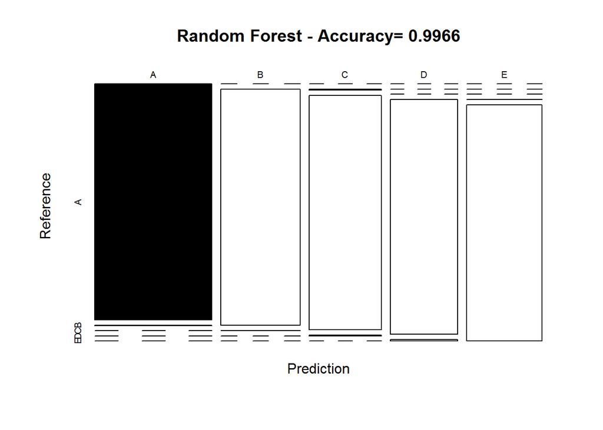

```r
plot(confmat$table, col=confmat$byClass, main=paste("Random Forest - Accuracy=", round(confmat$overall['Accuracy'],4)))
```

### 2. Decision Trees

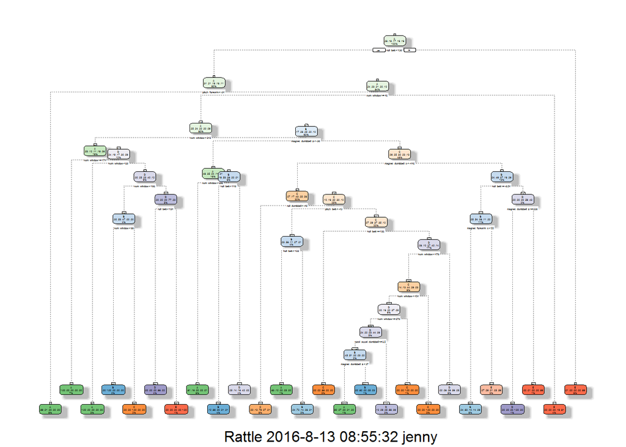

```r
set.seed(36363)
modFitDT <- rpart(classe ~ ., data=Training, method="class")
fancyRpartPlot(modFitDT)
```

```r
predictDT <- predict(modFitDT, newdata=testing, type="class")
confmatDT <- confusionMatrix(predictDT, testing$classe)
confmatDT
```

```
## Confusion Matrix and Statistics
##
##           Reference
## Prediction    A    B    C    D    E
##          A 1523   97    0   11    6
##          B   48  858   68   76   37
##          C    0   62  846   40    4
##          D   88   73  111  775  177
##          E   15   49    1   62  858
##
## Overall Statistics
##
##                Accuracy : 0.8258
##                  95% CI : (0.8159, 0.8354)
##     No Information Rate : 0.2845
##     P-Value [Acc > NIR] : < 2.2e-16
##
##                   Kappa : 0.7801
##  Mcnemar's Test P-Value : NA
##
## Statistics by Class:
##
##                      Class: A Class: B Class: C Class: D Class: E
## Sensitivity            0.9098   0.7533   0.8246   0.8039   0.7930
## Specificity            0.9729   0.9517   0.9782   0.9088   0.9736
## Pos Pred Value         0.9304   0.7893   0.8887   0.6332   0.8711
## Neg Pred Value         0.9645   0.9414   0.9635   0.9595   0.9543
## Prevalence             0.2845   0.1935   0.1743   0.1638   0.1839
## Detection Rate         0.2588   0.1458   0.1438   0.1317   0.1458
## Detection Prevalence   0.2782   0.1847   0.1618   0.2080   0.1674
## Balanced Accuracy      0.9414   0.8525   0.9014   0.8564   0.8833
```

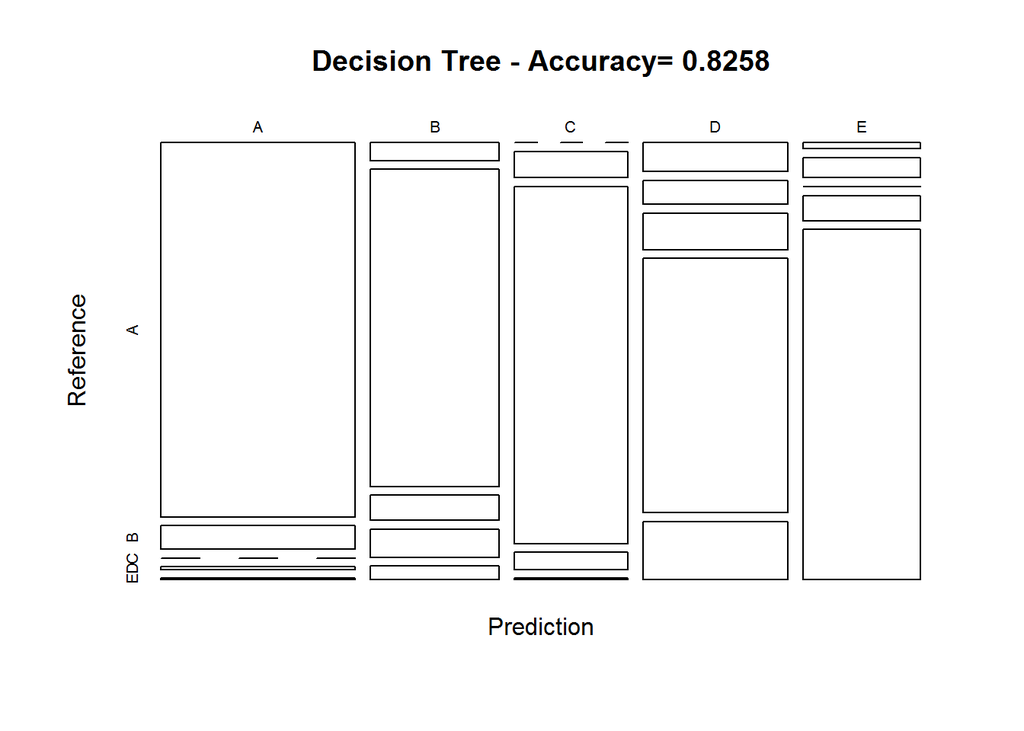

```r
plot(confmatDT$table, col=confmatDT$byClass, main=paste("Decision Tree - Accuracy=", round(confmatDT$overall['Accuracy'],4)))
```

### 3. Generalized Boosted Model

```r
set.seed(36363)
controlGBM <- trainControl(method="repeatedcv", number=5, repeats=1)
modFitGBM <- train(classe ~., data=Training, method="gbm", trControl=controlGBM, verbose=FALSE)
modFitGBM$finalModel
```

```
## A gradient boosted model with multinomial loss function.
## 150 iterations were performed.
## There were 53 predictors of which 39 had non-zero influence.
```

```r
predictGBM <- predict(modFitGBM, newdata=testing)
confmatGBM <- confusionMatrix(predictGBM, testing$classe)
confmatGBM
```

```
## Confusion Matrix and Statistics
##
##           Reference
## Prediction    A    B    C    D    E
##          A 1670   11    0    1    0
##          B    4 1109    6    2    3
##          C    0   15 1019   10    4
##          D    0    4    0  949   12
##          E    0    0    1    2 1063
##
## Overall Statistics
##
##                Accuracy : 0.9873
##                  95% CI : (0.9841, 0.99)
##     No Information Rate : 0.2845
##     P-Value [Acc > NIR] : < 2.2e-16
##
##                   Kappa : 0.9839
##  Mcnemar's Test P-Value : NA
##
## Statistics by Class:
##
##                      Class: A Class: B Class: C Class: D Class: E
## Sensitivity            0.9976   0.9737   0.9932   0.9844   0.9824
## Specificity            0.9972   0.9968   0.9940   0.9967   0.9994
## Pos Pred Value         0.9929   0.9867   0.9723   0.9834   0.9972
## Neg Pred Value         0.9990   0.9937   0.9986   0.9970   0.9961
## Prevalence             0.2845   0.1935   0.1743   0.1638   0.1839
## Detection Rate         0.2838   0.1884   0.1732   0.1613   0.1806
## Detection Prevalence   0.2858   0.1910   0.1781   0.1640   0.1811
## Balanced Accuracy      0.9974   0.9853   0.9936   0.9906   0.9909
```

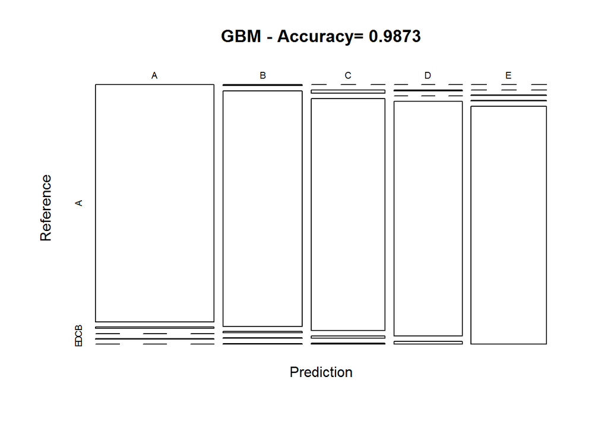

```r
plot(confmatGBM$table, col=confmatGBM$byClass, main=paste("GBM - Accuracy=", round(confmatGBM$overall['Accuracy'],4)))
```

### Result

```r
Result <- predict(modFit, newdata=test)
Result
```

```
##  [1] B A B A A E D B A A B C B A E E A B B B
## Levels: A B C D E
```